# Timeseries basics

author: Walter Djuric type: title  
font-family: ‘Arial’ date: 03/03/2015  
autosize: true

**ViennaR - Meetup 2015/I**

# Word from one of our Sponsors

[figure not shown]

# Overview

type:prompt width: 1440 height: 900

- timeseries (ts, zoo/xts)
- basic stuff (create, plot)
- financial data

# Timeseries basics and packages

type: section

For an overview of available packages …  
see CRAN task view:  
http://cran.r-project.org/web/views/TimeSeries.html

We will have a quick look at: - base R `ts` objects - `zoo` & `xts` class/package and their use for  
- financial timeseries

# Timeseries in base R

Base R timeseries object:

- ts

```r
(z <- ts(1:10, frequency = 4, start = c(2013, 2)))
```

```
     Qtr1 Qtr2 Qtr3 Qtr4
2013         1    2    3
2014    4    5    6    7
2015    8    9   10
```

# Multiple timeseries

```r
head(dat <- matrix(rnorm(48), 12,3), n = 3) # the data
```

```
           [,1]       [,2]       [,3]
[1,]  0.5843825  2.3220117  0.9607842
[2,]  1.6835275 -0.2930287 -1.1898761
[3,] -0.3142596 -0.8867444 -1.1199790
```

```r
mz <- ts(dat, start = c(2010, 1), end = c(2013,12), frequency = 12)
.preformat.ts(mz)[1:3,]
```

```
           Series 1   Series 2   Series 3
Jan 2010  0.5843825  2.3220117  0.9607842
Feb 2010  1.6835275 -0.2930287 -1.1898761
Mar 2010 -0.3142596 -0.8867444 -1.1199790
```

# plot.ts

```
plot(mz, lty=1:3, plot.type = 'single')
```

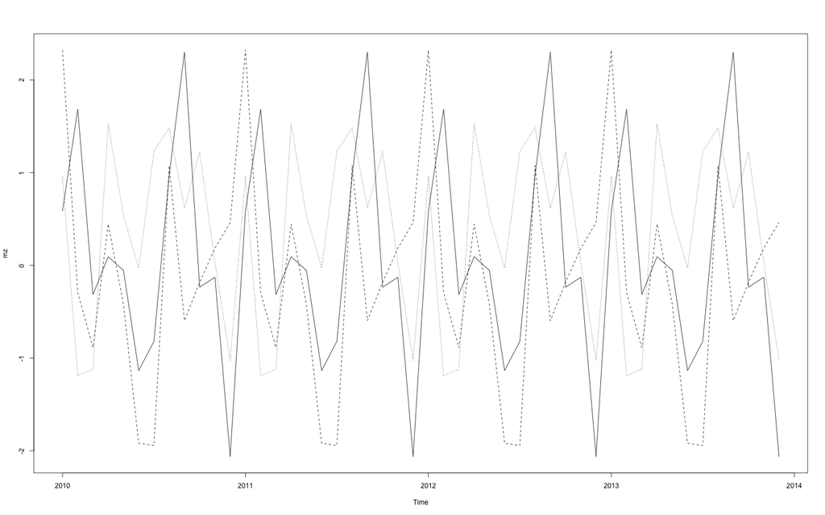

# In need of new class(es)/package(s)

type: subsection

The weakness of base R timeseries class lies in the limited scope of its methods.  
So some folks (A. Zeiles, G. Grothendieck, J. A. Ryan, J. M. Ulrich) decided to build package(s).

**zoo** and **xts** ended up as much more powerful alternatives with respect to available methods etc. to base R `ts`.  
So let’s have a look.

# zoo & xts

type: section

**xts** is a superset of the **zoo** package i.e. xts can do everything that zoo can do!  
Details are available in the package vignette …

```r
require(xts)
#vignette("xts")
```

```r
x <- 1:10; dt <- Sys.Date()+c(1:10)
ts <- xts(x, dt)
class(ts)
```

```
[1] "xts" "zoo"
```

The data `x` is epxected to be `numeric`.  
The time vector (or index) `dt` must be a supported date or time class: `Date, POSIXct, chron`.

# Multi-column data

type: subsection

```r
data(sample_matrix)
head(sample_matrix, 3)
```

```
               Open     High      Low    Close
2007-01-02 50.03978 50.11778 49.95041 50.11778
2007-01-03 50.23050 50.42188 50.23050 50.39767
2007-01-04 50.42096 50.42096 50.26414 50.33236
```

```r
class(sample_matrix)
```

```
[1] "matrix"
```

```r
str(sample_matrix)
```

```
 num [1:180, 1:4] 50 50.2 50.4 50.4 50.2 ...
 - attr(*, "dimnames")=List of 2
  ..$ : chr [1:180] "2007-01-02" "2007-01-03" "2007-01-04" "2007-01-05" ...
  ..$ : chr [1:4] "Open" "High" "Low" "Close"
```

```r
xts_mtx <- as.xts(sample_matrix, descr = 'new xts obj')
```

```r
str(xts_mtx)
```

```
An 'xts' object on 2007-01-02/2007-06-30 containing:
  Data: num [1:180, 1:4] 50 50.2 50.4 50.4 50.2 ...
 - attr(*, "dimnames")=List of 2
  ..$ : NULL
  ..$ : chr [1:4] "Open" "High" "Low" "Close"
  Indexed by objects of class: [POSIXct,POSIXt] TZ:
  xts Attributes:
List of 1
 $ descr: chr "new xts obj"
```

# Plotting timeseries

type: subsection

> Simple xts plot

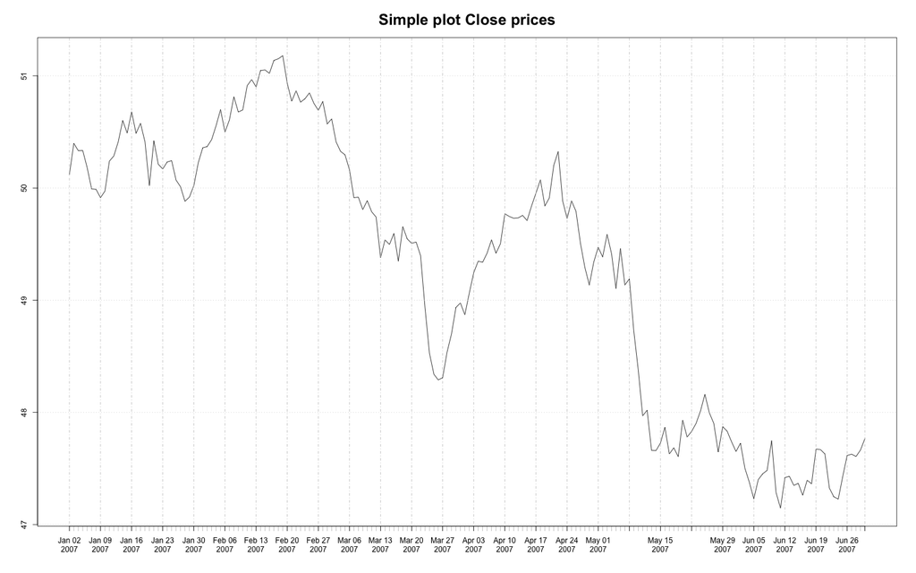

> Fancy xts plot

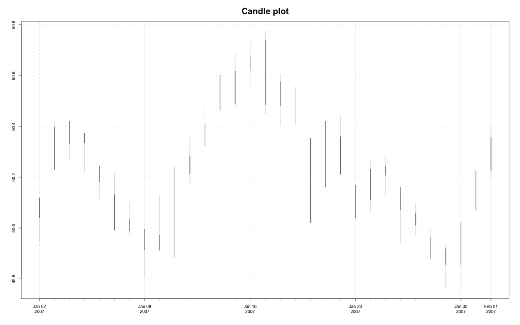

# Financial timeseries

type: section

Main packages …  
see CRAN task view:  
http://cran.r-project.org/web/views/Finance.html

Finally we will have a closer look into the **quantmod** package as well.

# quantmod

type: subsection title: false

```r
library(quantmod)
OMV <- getSymbols("OMV.VI", auto.assign = FALSE) #make sure internet connection is available
```

```r
class(OMV)
```

```
[1] "xts" "zoo"
```

```r
tail(OMV, 3)
```

```
           OMV.VI.Open OMV.VI.High OMV.VI.Low OMV.VI.Close OMV.VI.Volume
2015-03-11       24.89       24.94      24.40        24.67        571900
2015-03-12       24.67       25.04      24.67        24.86        421100
2015-03-13       24.95       24.95      24.11        24.34        474600
           OMV.VI.Adjusted
2015-03-11           24.67
2015-03-12           24.86
2015-03-13           24.34
```

# quantmod plot

type: subsection

```r
png(filename = "./figures/OMV_chart.png", width=1440, height=900)
chartSeries(OMV, subset="2013::2013",
            name = "OMV ohlc prices",
            show.grid = TRUE,
            minor.ticks = TRUE,
            color.vol = TRUE)
```

# quantmod plot cont’d

type: subsection

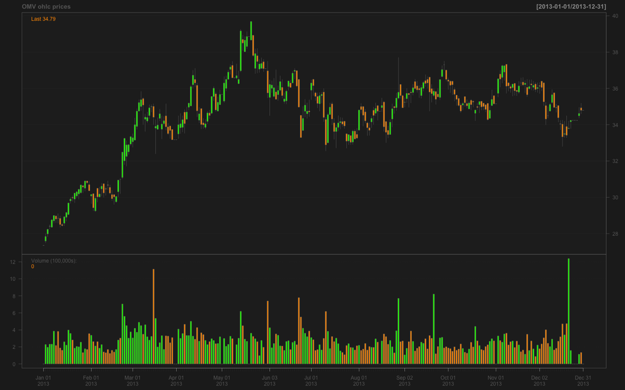

# Add an Indicator (e.g. Boillinger Bands)

type: subsection

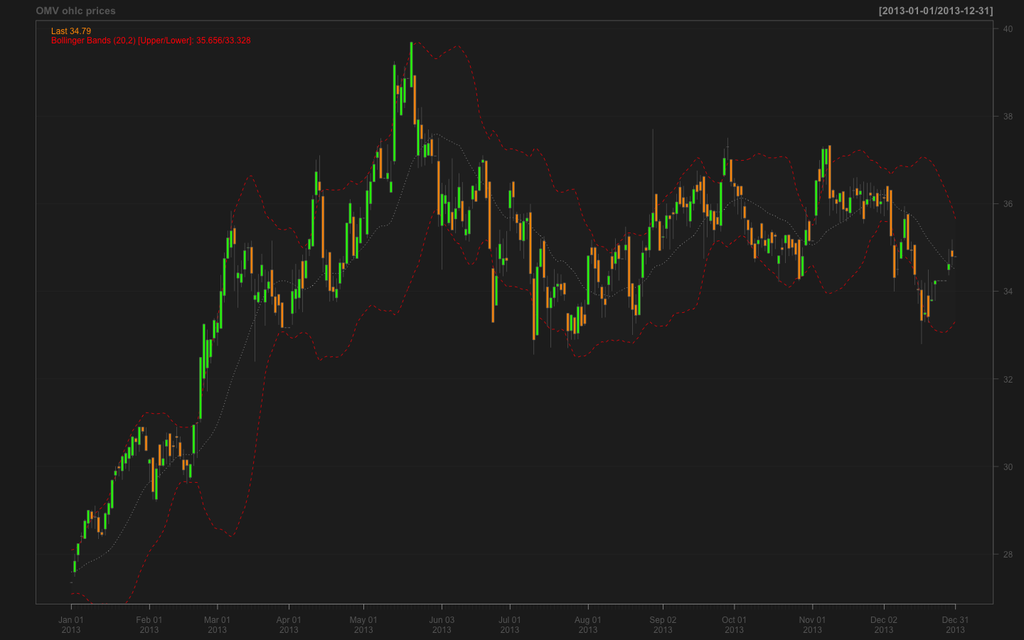

# TTR for quantmod

type: section

```r
library(TTR)
```

`quantmod` depends on `TTR` - which provides numerous indicators that can be added to our plots e.g.:

- Moving Averages (SMA, EMA, etc.)
- RSI
- MACD
- Stochastics
- Stock symbols
- etc.

# Add more indicators

type: subsection

[figure not shown]

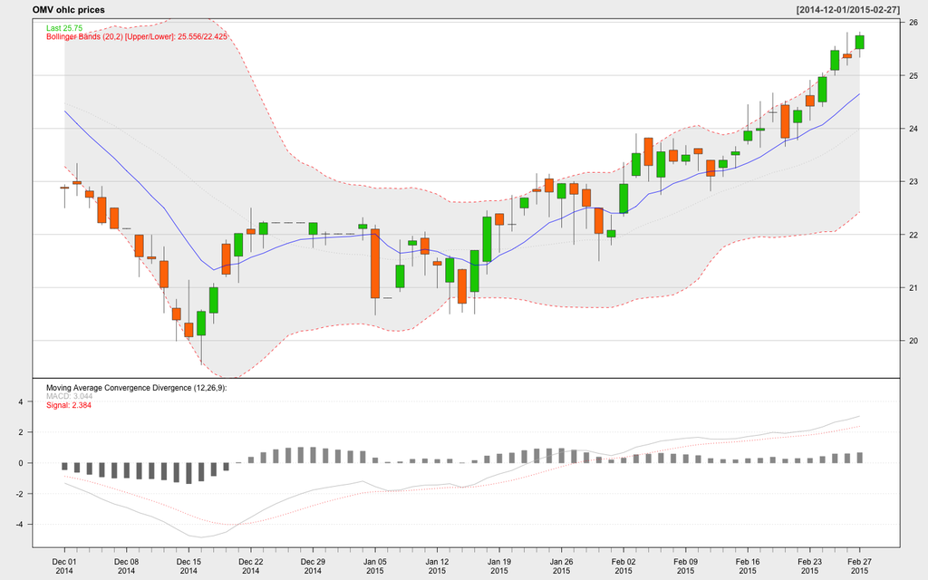

# Last (not least) a ggplot2 graph

type: subsection

```r
#Create prices and volumes
df <- OMV[ , c("OMV.VI.Adjusted", "OMV.VI.Volume")]
names(df) <- c("price", "vol")
#Create return col
df$ret <- diff(log(df[ , 1]))
df <- df[-1, ]#loose the first data-point as return is NA there
head(df, 4)
```

[output not shown]

# ggplot2 cont’d

type: subsection

Define return buckets - we utilize the `cut` function for that

```r
df$bucket <- cut(abs(df$ret), breaks = c(0, 0.03, 0.06, 0.25),
                  include.lowest = TRUE)
#Add mean column
df$avg <- NA
for ( i in 1:3 ) {
  group <- which( df$bucket == i )
  if ( length(group) > 0 ) {
    df$avg[group] <- mean(df$vol[group])
  }
}
```

```
ggplot(df) + geom_histogram(aes(x=vol)) + facet_grid(bucket ~ .) + geom_vline(aes(xintercept = avg), ...
```

[figure not shown]

# Thank you!

type: prompt

Hope to see you (again) at the next Meetup!